# q1_umar_razzaq_21020572

### Q1) Outlier Detection (20 Marks)

Outlier detection (also known as 'anomaly detection') is the process of finding observation points that deviate from other observations. Such observation points are called outliers or anomalies. In this question, you will employ simple visualization and statistical techniques to find the outliers and then, you will apply outlier detection algorithms.

You will be using forestfires.csv dataset.

**Note: You are required to submit the html files of both Q1 and Q2. Format should be q1_firsname_lastname_rollno.html**

```python
import seaborn as sns
import numpy as np
import pandas as pd
import matplotlib.pyplot as plt
from scipy.cluster.vq import kmeans
from sklearn.neighbors import LocalOutlierFactor
from matplotlib import cm
```

### Loading the dataset

```python
#loading the dataset
data_df = pd.read_csv("forestfires.csv")
data_df.head()
```

|  | month | day | FFMC | DMC | DC | ISI | temp | RH | wind | rain | area |
| --- | --- | --- | --- | --- | --- | --- | --- | --- | --- | --- | --- |
| 0 | mar | fri | 86.2 | 26.2 | 4.3 | 5.1 | 8.2 | 51 | 6.7 | 0.0 | 0.0 |
| 1 | oct | tue | 90.6 | 35.4 | 669.1 | 6.7 | 18.0 | 33 | 0.9 | 0.0 | 0.0 |
| 2 | oct | sat | 90.6 | 43.7 | 686.9 | 6.7 | 14.6 | 33 | 1.3 | 0.0 | 0.0 |
| 3 | mar | fri | 91.7 | 33.3 | 77.5 | 9.0 | 8.3 | 97 | 0.4 | 0.2 | 0.0 |
| 4 | mar | sun | 89.3 | 51.3 | 102.2 | 9.6 | 11.4 | 99 | 1.8 | 0.0 | 0.0 |

```python
data = data_df.copy()
data = data.dropna()
```

### **Box-Plots**

Plot box-plots for "**FFMC**"

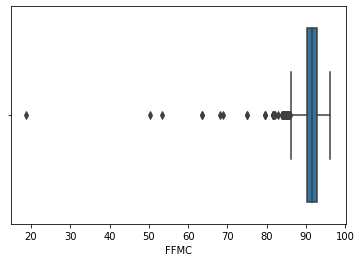

```python
#Write code here
sns.boxplot(x=data.FFMC)
```

Plot box-plots for "**Day Vs Temp**" and "**Month Vs Temp**" and comment on your results.

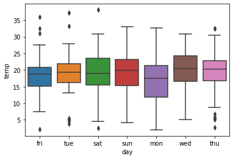

```python
#Write code here for day vs temp
sns.boxplot(x=data.day,y=data.temp)
```

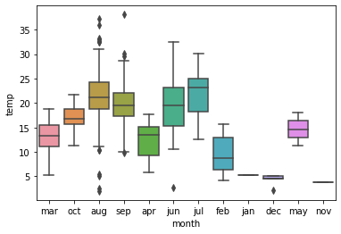

```python
#Write code here for month vs temp
sns.boxplot(x=data.month,y=data.temp)
```

Days: Temprature is almost the same through out the week

Month: Temprature varies across months and some months have more variability in temprature than others

### **Scatter-plot**

Plot scatter-plot for "**DC Vs Area**". Comment if it shows any outliers. Use matplotlib.pyplot library for scatter-plot.

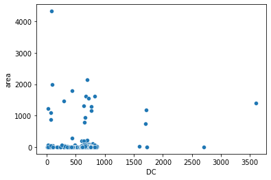

```python
#Write code here
sns.scatterplot(x=data.DC,y=data.area)
```

[output not shown]

### **Standard Deviation**

If certain point is some standard deviation(threshold) away from the mean it can be identified as outlier. For **Area and Temp**, output the list of values that are identified as outliers using optimal value of threshold.

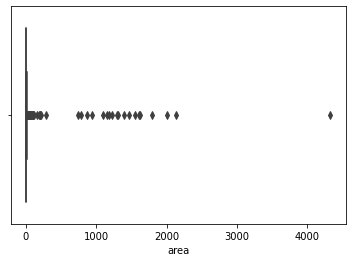

```python
from numpy import mean
from numpy import std
#Write code here

# First plotting both variables to get a better idea of the distribution
sns.boxplot(x=data.area)
```

```python
upper_bound = mean(data.area)+2*std(data.area)
# as the data has a chi square distribution hence only looking for outliers in the positive tail
print('list of values that are identified as outliers',data.area[(data.area > upper_bound)].values,sep='\n')
```

```
list of values that are identified as outliers
[1314.    942.4  4328.4  1392.4   779.5   866.   2000.   1609.4  2137.
 1090.84 1224.24 1786.45 1463.52 1545.18 1622.18 1156.04 1290.03 1174.63
  746.28]
```

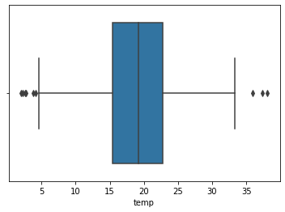

```python
sns.boxplot(x=data.temp)
```

```python
upper_bound = mean(data.temp)+2*std(data.temp)
lower_bound = mean(data.temp)-2*std(data.temp)
print('list of values that are identified as outliers',data.temp[(data.temp > upper_bound) | (data.temp < lower_bound)].values,sep='\n')
```

```
list of values that are identified as outliers
[ 2.   5.5  5.3  5.3  5.8  5.8  5.1 38.1  4.8  5.1  5.1  4.6  4.6  4.6
  4.6  2.2  5.1  4.2  5.2  5.3  4.6  5.1  4.6 32.4  2.7 33.1  5.4 32.4
 32.4 32.6 37.3 33.3 35.9  2.6  3.8]
```

- **What standard deviation threshold did you use to detect the outliers and why?**

### *IQR*

For **Area and Temp**, output the list of values that are identified as outliers on the basis of their IQR values.

For this, calculate the first (q1) and third quartile (q3). An outlier is then a data point that lies outside the interquartile range. That is:

- *Lower outlier= Q1 - (k x IQR)*
- *Higher outlier= Q3 + (k x IQR)*

Choose an appropriate 'k' for this part.

```python
#Write code here
q1_area, q3_area = np.percentile(data.area, [25,75])
q1_temp, q3_temp = np.percentile(data.temp, [25,75])

# no need for lower bound for area as chi-square distribution
# lower_area = q1_area - (1.5 * (q3_area - q1_area))

upper_area = q3_area + (1.5 * (q3_area - q1_area))
lower_temp = q1_temp - (1.5 * (q3_temp-q1_temp))
upper_temp = q3_temp + (1.5 * (q3_temp-q1_temp))


print('Outliers of area: ', data.area[data.area > upper_area].values)
print()
print('Outliers of temp: ', data.temp[(data.temp > upper_temp) | (data.temp < lower_temp)].values)
```

```
Outliers of area:  [1314.    942.4  4328.4  1392.4   779.5   866.   2000.   1609.4  2137.
   19.23   23.41   24.23   26.     26.13   27.35   28.66   28.66   29.48
   30.32   31.72   31.86   32.07   35.88   36.85   37.02   37.71   48.55
   49.37   58.3    64.1    71.3    88.49   95.18  103.39  105.66  154.88
  196.48  200.94  212.88 1090.84   22.03   24.77 1224.24 1786.45 1463.52
 1545.18   34.36 1622.18  111.22 1156.04   28.19 1290.03   39.35 1174.63
   42.87   24.59   28.74   30.18   70.76   51.78  746.28  185.76   82.75
   61.13   38.48   70.32  278.53   26.43   46.7    43.32   40.54   49.59
   54.29]

Outliers of temp:  [ 2.  38.1  2.2  4.2  2.7 37.3 35.9  2.6  3.8]
```

- **What k-value did you use to detect the outliers and why?**

I used 1.5 as K because that is the standard used for normal and chi-sq dist

- **Which parameter (IQR or standard deviation) is better outlier detection? Give reason.**

Standard dev is better because you can select the exact range in std. On the other hand in IQR you have to use these ranges to remove the percentage of data you want.

### **Outlier Detection using LOC (Local Outlier Factor)**

LOF uses density-based outlier detection to identify local outliers. An anomaly score is assigned to each sample which measures the local deviation of density of a this sample with respect to its neighbors.

```python
#Removing month and day colums
data = data.drop('month', axis = 1)
data = data.drop('day', axis = 1)
```

**1.** Tranform the features by scaling them to a given range(e.g. 0-1):

```python
from sklearn.preprocessing import MinMaxScaler
#Write your code here for minmax scaling
min_max_scale = MinMaxScaler(feature_range=(0, 1))
min_max_scale = min_max_scale.fit_transform(data)
min_max_scale
```

```
array([[0.87096774, 0.08649207, 0.        , ..., 0.70652174, 0.        ,
        0.        ],
       [0.92774194, 0.11819435, 0.18481555, ..., 0.07608696, 0.        ,
        0.        ],
       [0.92774194, 0.14679531, 0.18976398, ..., 0.11956522, 0.        ,
        0.        ],
       ...,
       [0.8116129 , 0.19159201, 0.18384254, ..., 0.70652174, 0.        ,
        0.00257832],
       [0.97677419, 0.49931082, 0.16969225, ..., 0.41304348, 0.        ,
        0.        ],
       [0.78451613, 0.00654721, 0.02846738, ..., 0.4673913 , 0.        ,
        0.        ]])
```

**2.** Implement LOC algorithm using sklearn. Choose the parameters that will be passed into the function:

```python
#write your code here
neigh = 10
cont = 0.1
lof_scale = LocalOutlierFactor(n_neighbors = neigh, contamination = cont)
lof_scale = lof_scale.fit_predict(data)
lof_scale
```

```
array([ 1,  1,  1,  1, -1,  1,  1, -1,  1,  1,  1,  1, -1,  1,  1,  1,  1,
        1,  1,  1,  1, -1,  1,  1,  1,  1, -1,  1,  1,  1,  1,  1,  1,  1,
        1,  1,  1,  1,  1,  1,  1,  1,  1,  1,  1,  1,  1,  1,  1,  1,  1,
        1,  1,  1,  1,  1,  1,  1,  1,  1,  1,  1,  1,  1,  1,  1,  1,  1,
        1,  1,  1,  1,  1,  1,  1,  1,  1,  1,  1,  1,  1,  1,  1,  1,  1,
       -1,  1,  1,  1,  1,  1, -1,  1,  1,  1,  1,  1,  1, -1,  1,  1,  1,
       -1,  1,  1,  1, -1,  1,  1,  1,  1,  1,  1, -1,  1,  1,  1,  1,  1,
        1,  1,  1,  1,  1,  1,  1,  1,  1,  1,  1,  1,  1,  1,  1,  1,  1,
        1,  1,  1,  1,  1,  1,  1,  1,  1,  1,  1,  1,  1,  1,  1,  1,  1,
        1,  1,  1,  1,  1,  1,  1,  1,  1,  1,  1,  1,  1,  1,  1,  1,  1,
        1,  1,  1,  1,  1,  1,  1,  1,  1,  1,  1,  1,  1,  1,  1,  1,  1,
        1,  1,  1,  1,  1,  1,  1,  1,  1,  1,  1,  1,  1,  1,  1,  1,  1,
        1,  1,  1,  1,  1,  1,  1, -1,  1,  1,  1,  1, -1,  1, -1,  1, -1,
       -1,  1,  1, -1, -1,  1, -1, -1, -1, -1, -1,  1, -1,  1, -1,  1,  1,
        1,  1,  1,  1, -1,  1,  1,  1,  1,  1,  1,  1,  1,  1,  1,  1,  1,
```

[output cut: 16 more lines]

- **What value did you use for the 'n_neighbours'?**

```python
print("I choose",neigh)
```

```
I choose 10
```

**3.** Print the length of outliers returned.

```python
print("The length of the outliers returned is", len(np.where(lof_scale == -1)[0]))
```

```
The length of the outliers returned is 52
```

### **Isolation Forest**

Isolation Forest is an outlier detection algoritm that is based on the Decision Trees. It spearates the outliers by randomly selecting a certain attribute and then randomly selecting a split value between the max and min values of this feature.

**1.** Implement Isolation Forest algorithm using sklearn. Choose the parameters that will be passed into the function:

```python
#Write your code here
from sklearn.ensemble import IsolationForest
max_s = 50
i_forest = IsolationForest(max_samples = max_s)
i_forest_scale = i_forest.fit(data)
i_forest_scale = i_forest_scale.predict(data)
i_forest_scale
```

```
array([ 1,  1,  1, -1,  1,  1,  1,  1,  1,  1,  1,  1, -1,  1,  1,  1,  1,
        1,  1,  1,  1,  1,  1,  1,  1,  1,  1,  1,  1,  1,  1,  1,  1,  1,
        1,  1,  1,  1,  1,  1, -1,  1,  1,  1,  1,  1,  1,  1,  1,  1,  1,
        1,  1,  1,  1,  1,  1,  1, -1, -1,  1,  1,  1,  1,  1,  1,  1,  1,
        1,  1,  1,  1,  1,  1,  1, -1,  1,  1,  1,  1,  1, -1,  1,  1,  1,
       -1,  1,  1,  1,  1,  1, -1,  1,  1,  1,  1, -1, -1, -1,  1,  1,  1,
       -1,  1, -1,  1, -1,  1,  1,  1,  1,  1,  1,  1, -1,  1,  1,  1, -1,
        1,  1,  1,  1, -1,  1,  1,  1,  1,  1, -1, -1,  1,  1,  1,  1,  1,
        1,  1,  1,  1,  1,  1,  1,  1,  1,  1,  1,  1,  1,  1,  1,  1,  1,
        1,  1,  1,  1,  1,  1,  1,  1,  1,  1,  1,  1, -1,  1,  1,  1,  1,
        1,  1,  1,  1,  1,  1, -1,  1,  1,  1,  1,  1, -1,  1,  1,  1,  1,
        1,  1,  1,  1,  1,  1,  1,  1,  1, -1,  1,  1, -1,  1,  1, -1,  1,
        1,  1,  1,  1,  1,  1,  1, -1,  1,  1,  1,  1,  1,  1,  1,  1,  1,
        1,  1,  1,  1,  1,  1,  1,  1,  1,  1,  1,  1, -1,  1,  1,  1,  1,
       -1, -1,  1, -1,  1, -1,  1,  1,  1,  1,  1,  1,  1,  1,  1,  1,  1,
```

[output cut: 16 more lines]

- **What value did you use for the 'max_samples'?**

```python
print("value of max-samples is",max_s)
```

```
value of max-samples is 50
```

**2.** Print the length of outliers returned.

```python
len(np.where(i_forest_scale == -1)[0])
```

```
95
```

- **Compare the results from both LOC and Isolation Forest:**